# Two-Stage Product Recommendation for the Olist Marketplace

**Capstone: Post Graduate Diploma in AI & Machine Learning**

Daniel Jethro Monzada · July 2026

~100k real Brazilian eCommerce orders (2016-2018) · candidate generation + supervised re-ranking · fairness-audited

Repo: `github.com/jmonzada/ecommerce-recommender-capstone`

Data: Brazilian E-Commerce Public Dataset by Olist (Kaggle, CC BY-NC-SA 4.0)

## One number, and the shape of the answer

**96.9% of Olist's 96,096 customers have placed exactly one order.**

- Business question: can a recommender pull customers into a **second purchase**, and widen exposure beyond bestsellers?
- Seller angle: Olist's pitch to small merchants is *exposure*, and a popularity-only feed quietly breaks it.

**Architecture: two stages, like production systems**

1. **Candidate generation**: item-item CF, content similarity, truncated SVD, popularity, hybrid blend
2. **Supervised ranker**: LR / RF / XGBoost scoring "will this (customer, product) pair convert?"

The ranker is feature-based, which is where SHAP, PDP/ICE and the fairness audit genuinely work.

*Where it lands: on a temporally clean holdout the full pipeline beats shortlist-only by **+20%** (CI excludes zero); see slide 7.*

## Evaluation protocol (the load-bearing part)

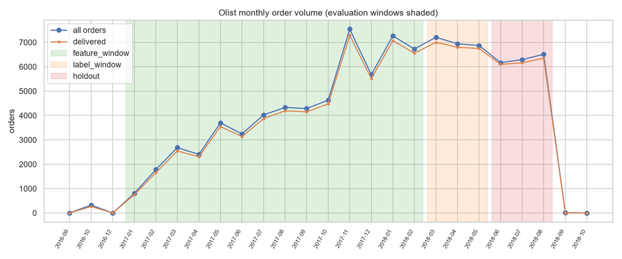

- **Three temporal windows** (`configs/windows.yaml`): features 2017-01 to 2018-02 · labels 2018-03 to 2018-05 · holdout 2018-06 to 2018-08 (post-Aug tail collapses, dropped)
- **Every aggregate** (popularity, similarities, SVD factors, RFM…) computed on the feature window only; audit cells assert max timestamps, including review *creation* dates (caught 6.7% leakage)
- Candidate gen: **leave-last-order-out** on 2,789 repeat buyers (840 tuning / 1,949 evaluated), bootstrap CIs, K = 10/50/100 + MRR
- Ranker: **GroupKFold by customer**; negatives 1:4, half hard (from candidate lists), half random; random-only negatives make the task popularity-easy and mismatch serving (the Step 3 random-negative screen already sat at AUC ≈ 0.81 with weaker features)

## EDA that shaped the design

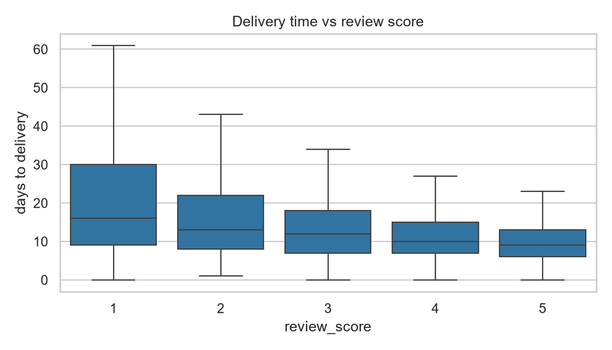

- Late deliveries (8%) average **2.57 stars vs 4.29** on time, which is why customer-to-seller **haversine distance** became a pair feature
- Only **2.09%** of label-window pairs have any feature-window history, so cold-start routing is core scope, not an afterthought
- Prices heavy-tailed (median R$75, p99 ≈ R$890), so price features are winsorised
- Southeast = 68.6% of customers, North = 1.9%, which sets the minimum-group rules for the fairness audit

## Stage 1: candidate generation (repeat buyers, leave-last-order-out)

| Model | Hit@10 | 95% CI | MRR | Coverage | Long-tail |
| --- | --- | --- | --- | --- | --- |
| Popularity | 0.031 | [0.023, 0.038] | 0.013 | 0.0003 | 0.00 |
| Item-item CF | 0.055 | [0.045, 0.065] | 0.037 | 0.042 | 0.83 |
| Content-based | 0.171 | [0.154, 0.187] | 0.135 | **0.377** | 0.79 |
| SVD (k=256) | 0.054 | [0.045, 0.065] | 0.046 | 0.019 | 0.03 |
| **Hybrid (w=0.25)** | **0.203** | [0.184, 0.221] | 0.138 | 0.371 | 0.76 |

- Paired per-user difference, hybrid minus content: **+0.032 [+0.022, +0.042]**, a real winner, not noise
- Honesty note: **62-69% of hits are repurchases**; CF is signal-starved (co-purchase matrix has 8,710 pairs)
- Popularity's coverage is 10 products. That's the baseline the marketplace ships without ML.
- Caveat: LOO trades temporal strictness for coverage; decision-grade numbers are the end-to-end table (slide 7)

## Stage 2: conversion rankers (sampled negatives give relative numbers)

| Ranker | CV AUC | Holdout AUC | PR-AUC | F1@τ |
| --- | --- | --- | --- | --- |
| Logistic regression | 0.697 | 0.785 | 0.414 | 0.475 |
| Random forest | 0.852 | 0.865 | 0.619 | 0.569 |
| **XGBoost** | 0.853 | 0.864 | 0.614 | **0.578** |

- Tuned via randomized search, `GroupKFold` by customer; τ picked on **out-of-fold** predictions
- RF train AUC 0.945 vs holdout 0.865; the overfit gap LR doesn't have; XGBoost wins on F1 with a smaller gap
- These metrics **compare rankers against each other**; sampled 1:4 negatives make absolute values meaningless

## The headline table: end-to-end on 18,390 holdout customers

| Pipeline | Hit@10 | 95% CI | NDCG@10 |
| --- | --- | --- | --- |
| Popularity only | 0.0114 | [0.0099, 0.0130] | 0.0052 |
| Stage 1 only (routed hybrid) | 0.0122 | [0.0105, 0.0139] | 0.0062 |
| Two-stage + LR | 0.0061 | [0.0051, 0.0073] | 0.0032 |
| Two-stage + RF | 0.0132 | [0.0115, 0.0150] | 0.0064 |
| **Two-stage + XGBoost** | **0.0146** | [0.0128, 0.0165] | 0.0069 |

- Paired per-customer difference vs Stage 1: **+0.0024 [+0.0008, +0.0041]**, i.e. **+20% relative**, CIs exclude zero
- Re-ranking is not free: the LR re-rank *halves* performance; stage 2 must earn its place
- Routing reality: **98.5% of holdout customers are cold**, served regional/global popularity; warm cohort (n=277) is underpowered and slightly prefers raw hybrid, flagged as future work, not hidden

## Explainability: SHAP on the ranker

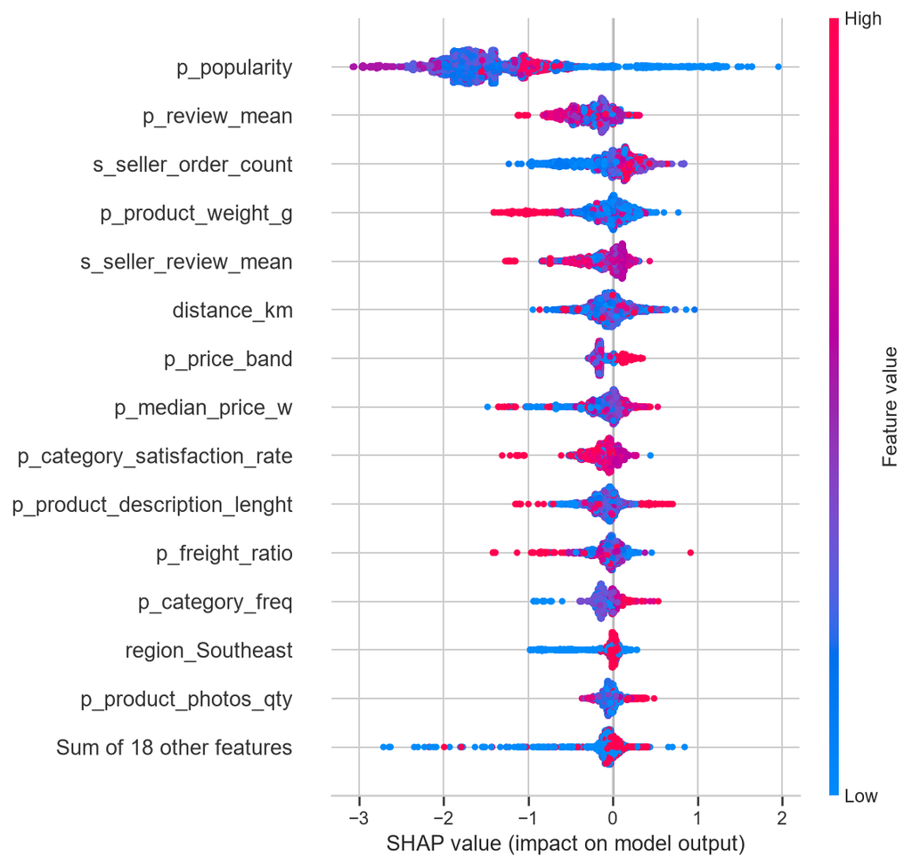

## Fairness audit: region as socioeconomic proxy (IBGE-cited)

Evaluation population = **Stage-1 candidate lists** (919,500 pairs); per-user random negatives would fake parity. Groups under n<30 positives suppressed (North).

| Region | TPR@τ | AUC |
| --- | --- | --- |
| Northeast | **0.222** [0.139, 0.319] | **0.825** |
| Center-West | 0.100 | 0.679 |
| South | 0.031 | 0.709 |
| Southeast | 0.028 | 0.714 |

- **TPR gap 0.194, favouring the Northeast**, and it persists in final lists (NE hit@10 0.031 vs 0.010-0.014)
- Mechanism found: Stage-1 **retrieval recall** is already higher for NE (0.043 vs 0.025-0.032); the disparity starts at candidate generation, not the ranker
- Fairness-through-unawareness buys nothing: dropping geography features costs accuracy (AUC 0.723 to 0.713) while gaps barely move; the τ-fixed TPR-gap widening (0.194 to 0.292) is partly a calibration artefact; freight & price encode geography anyway

## Provider-side bias & mitigations (matched before/after)

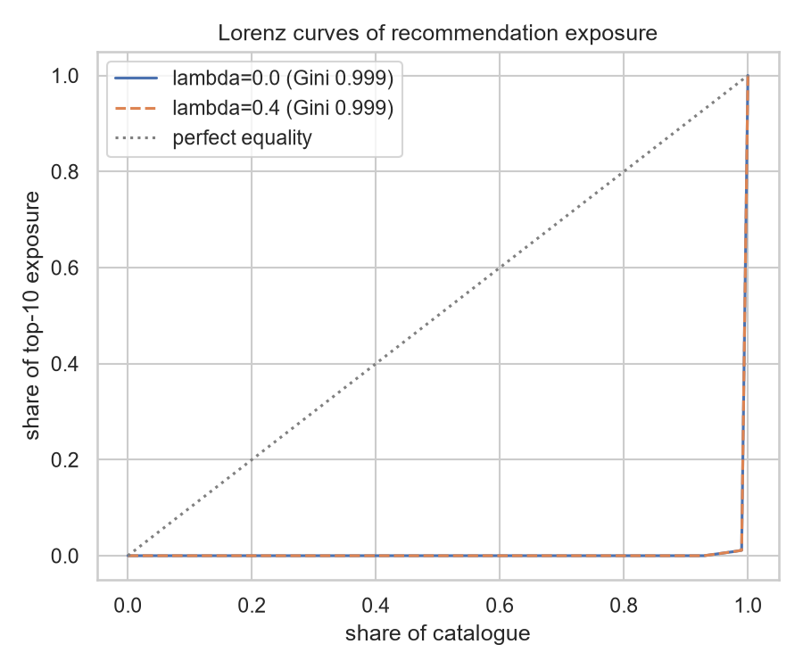

Exposure Gini **0.9986**; small sellers = 5.9% of catalogue, **0.02% of top-10 slots**.

| Mitigation | Result |
| --- | --- |
| ThresholdOptimizer (region) | Honest negative, didn't transfer to holdout |
| Score-penalty re-rank (λ sweep) | Inert; bias sits at *candidate generation* |
| Candidate-stage exploration | **Backfired: -73% hits** (the anti-popularity gradient punishes injected popular-ish items) |
| **Reserved-slot injection (3 of 10)** | **-14.5% Hit@10** for coverage 0.071 to 0.102, long-tail ×2.1, small sellers ×4.3 |

South pays the most: paired Δ -0.0045 [-0.0078, -0.0021], reported and gated on fresh-window validation before serving.

## From notebooks to a running system

- **Serving:** FastAPI `GET /recommend/{customer_id}` runs the *exact evaluated pipeline* (`src/pipeline.py` shared with the audit notebook); cold-start routing built in; Docker image bakes data + artefacts
- **MLOps:** configs in YAML, MLflow on every training run, CI (ruff + 38 tests) green since first push, monitoring plan (routing-share drift, then score PSI, then online hit-rate, then monthly exposure), rollback = previous git tag
- **GenAI (Step 9):** each recommendation's TreeSHAP signals become value-aware plain-English glosses, then one grounded Claude sentence, cached & committed; the grounding bug we caught (asserting a region for an unknown visitor) is preserved as evidence
- Demo video: `docs/media/demo.mp4` (41s, all three routes + explanations)

## Limitations & what I'd do next

**Limitations (also in the report, not fine print):**

- All numbers are **offline proxies**; validating uplift needs an A/B test
- Warm-cohort re-rank question is underpowered (n=277); route-conditional re-ranking is the obvious experiment
- Repurchase drives most personalisation hits; CF is starved at 1.04 products/order
- Fairness mitigation trade-off selected on the audit window, so **fresh-window validation before enabling**

**Next:** online experiment on repeat buyers · route-conditional re-rank · richer content features (the dataset has no text/images) · category-level objectives for cross-sell

**Everything reproducible:** seeded runs, pinned configs, committed artefacts, one-command serving.